# PA1_template

Denis

7 января 2019 г

# Reproducible Research: Course project 1 (Coursera Data Science Spec.)

This document was created as part of a course project with the Reproducible Research course at Coursera.com. In this project, the student is expected to study a dataset covering the activities of a volunteer tracking their physical activity, answer a range of questions regarding the dataset and provide an overview of the activity pattern it suggests.

Full description of the project and the tasks it involves is available in the forked repository.

## Step 0: Download the Data

As a first step in our analysis, we download the dataset, unzip it and read it into R.

```r
zipUrl <- "https://d396qusza40orc.cloudfront.net/repdata%2Fdata%2Factivity.zip"
zipFile <- "repdata_data_activity.zip"

if (!file.exists("activity.csv")) {
  download.file(zipUrl, zipFile)
  unzip(zipFile)
}

rm(zipFile, zipUrl)

data <- read.csv("activity.csv")
```

## Step 1: Total number of steps per day, mean and median

Now that the data have been downloaded and read, we can start to dig in for some actual analysis.

First, we will take a look at the total number of steps per day, plotting it as a histogram and, for now, ignoring any NAs the data happen to have.

```r
library(dplyr)
```

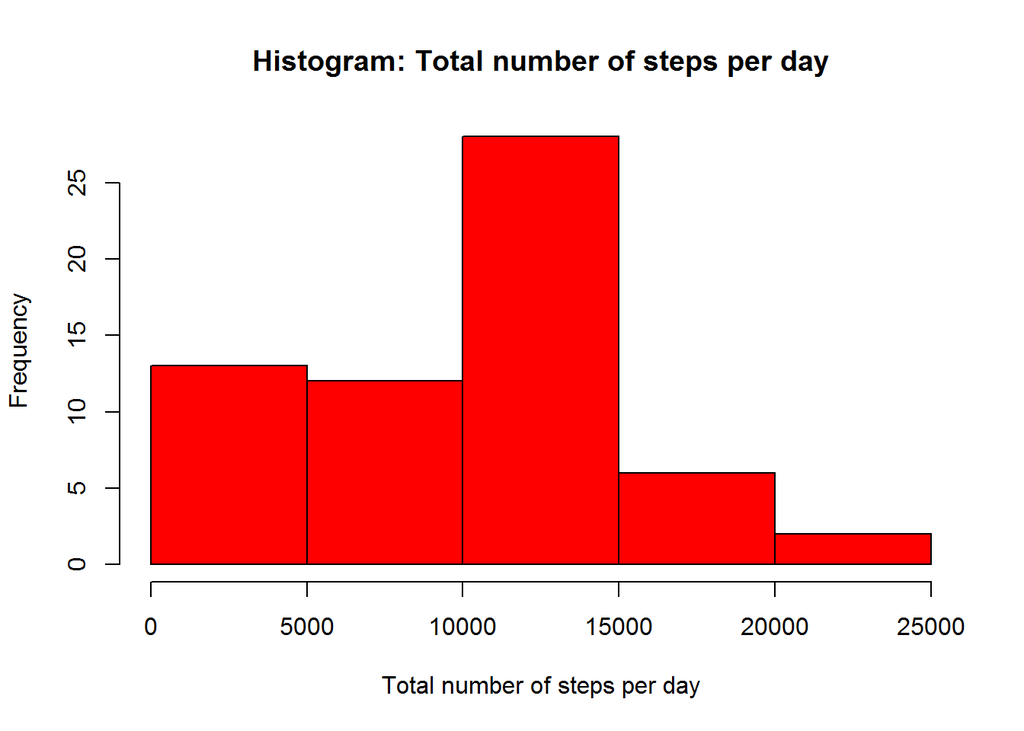

```r
dataGr <- group_by(data, date)
sumSteps <- summarize(dataGr, steps = sum(steps, na.rm = T))
hist(sumSteps$steps, main = "Histogram: Total number of steps per day", xlab = "Total number of steps per day", col = "red")
```

As we can see, the subject would most often make between 10000 and 15000 steps per day.

Now, let us take a look at the mean and median values for the steps per day total:

```r
mean(sumSteps$steps)
```

```
## [1] 9354.23
```

```r
median(sumSteps$steps)
```

```
## [1] 10395
```

## Step 2: Daily Activity Pattern

In this section, we will take a look at the subject’s daily activity pattern. However, as per the course project’s description, first, we have to impute the data. Here, I desided to base the imputation on the mean for the target time interval.

### Step 2.1: Imputing the Data

Before imputing the data, let us take a look at how many NAs we are dealing with, and what percent of the evaluation is missing.

```r
sum(is.na(data$steps))
```

```
## [1] 2304
```

```r
(sum(is.na(data$steps))/length(data$steps))*100
```

```
## [1] 13.11475
```

Now, we will create a new dataset, identical to the first one, and replace the missing values for the steps variable in line with the means for their respective intervals, rounding them downwards.

```r
data2 <- data
means <- numeric()
for (i in 1:sum(is.na(data2$steps))) {
  means <- c(means, floor(mean(data$steps[data$interval == data2$interval[is.na(data2$steps)][i]], na.rm = T)))
}
data2$steps[is.na(data2$steps)] <- means
```

### Step 2.2: Comparing the imputed dataset against the original one

With a new dataset in our hands, we will now see how it is different from the one we started with. First, let us take a look at the new histogram for total number of steps per day:

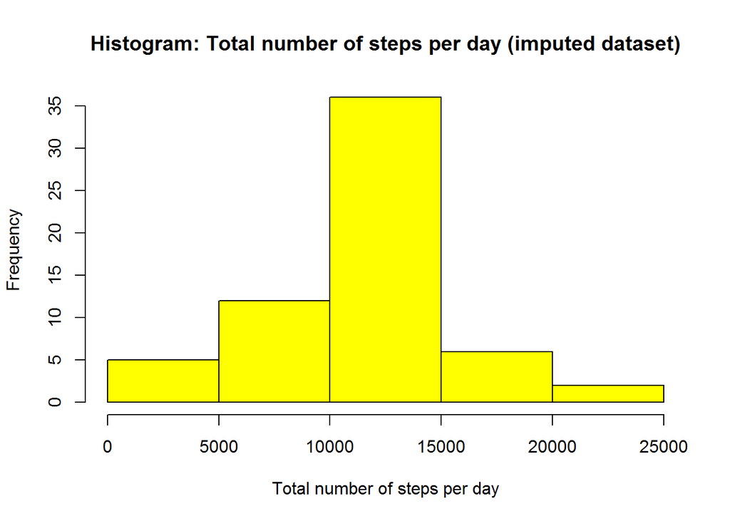

```r
dataGr2 <- group_by(data2, date)
sumSteps2 <- summarize(dataGr2, steps = sum(steps, na.rm = T))
hist(sumSteps2$steps, main = "Histogram: Total number of steps per day (imputed dataset)", xlab = "Total number of steps per day", col = "yellow")
```

As we can see, even more data is now clustered in the centre. We can also take a look at the new mean and median for the set:

```r
mean(sumSteps2$steps)
```

```
## [1] 10749.77
```

```r
median(sumSteps2$steps)
```

```
## [1] 10641
```

We can note that both the mean and the median have moved up.

### Step 2.3: Plotting the Daily Activity Pattern

Now we can use our new dataset to calculate and plot the daily activity pattern of the subject and identiify the interval of peak activity:

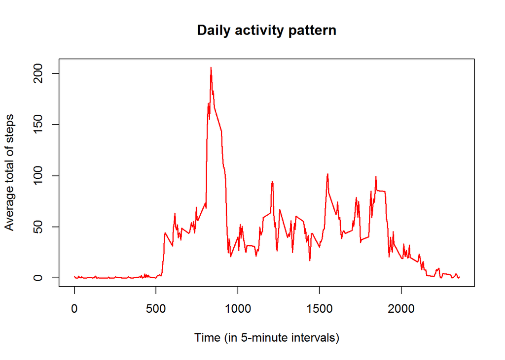

```r
data2Gr <- group_by(data2, interval)
avgSum <- summarize(data2Gr, steps = mean(steps))
plot(avgSum$interval, avgSum$steps, type = "l", lwd = 1.5, col = "red", main = "Daily activity pattern", xlab = "Time (in 5-minute intervals)", ylab = "Average total of steps")
```

```r
avgSum$interval[which.max(avgSum$steps)]
```

```
## [1] 835
```

## Step 3: Weekend vs. Weekday Activity Pattern

Finally, let’s see if there’s a difference in the activity patterns dispplayed by the subject on weekends and weekdays. First, let’s add a new Weekday factor variable to our imputed dataset:

```r
wdays <- weekdays(as.Date(data2$date, "%Y-%m-%d"))
wdays[wdays == "суббота" | wdays == "воскресенье"] <- "weekend"
wdays[wdays != "weekend"] <- "weekday"
data2 <- mutate(data2, weekday = as.factor(wdays))
rm(wdays)
```

Now, let’s calculate the patterns for weekends and weekdays and plot them:

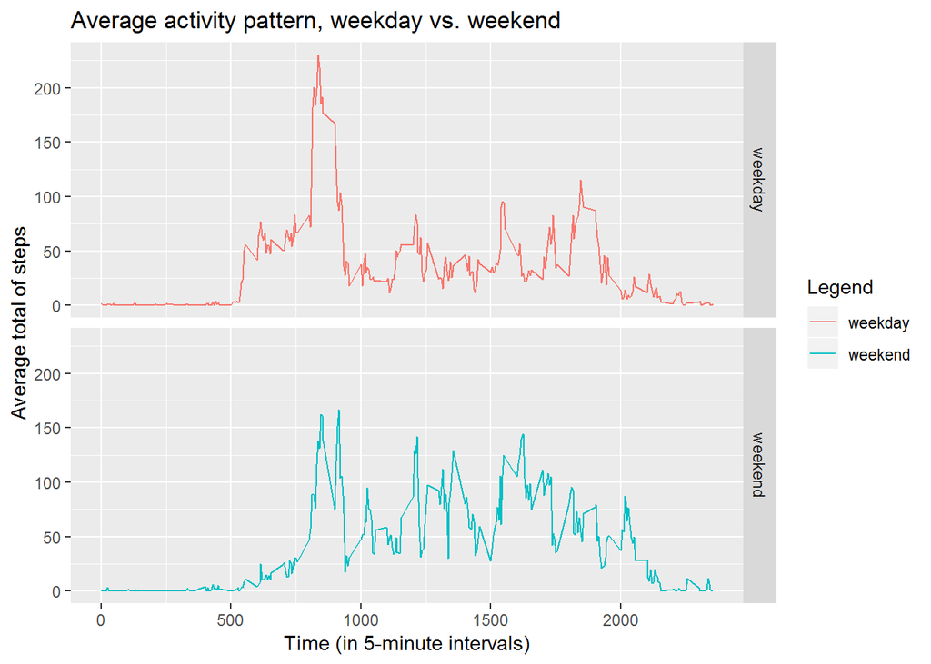

```r
data2Gr <- group_by(data2, weekday, interval)
wkdaySum <- summarize(data2Gr, steps = mean(steps))
rm(data2Gr)

library(ggplot2)
ggplot(wkdaySum, aes(interval, steps, color = weekday)) + facet_grid(weekday ~ .) + geom_line() + labs(title = "Average activity pattern, weekday vs. weekend", x = "Time (in 5-minute intervals)", y = "Average total of steps", color = "Legend")
```

```r
rm(data2, wkdaySum)
```

As we can see, while the weekday pattern is quite consistent with the one we plotted on the previous step, the weekend pattern reveals a significantly more even distridution of activity.